**Introduction**

The questions that I am trying to address through this data analysis project are jotted down below:

1)What are the predictor variables closely associated with the chest pain type predictor variable or Is there any way can the type of chest pain type be predicted by the use other different predictor variables that are closely associated?

2)Can the chest pain type be predicted with the help of different predictor variables which are closely associated?

*The explanation of the predictor variables is given in the table below:*

[output not shown]

Along this project I am going to use different set analytical techniques applicable for regression to predict my categorical variable type of chest pain.The regression techniques I am going to use are regression tree models,SVM Regression, clustering techniques,lasso ridge analysis to access the chest pain type.

2.Type of analysis

I will be using the following analysis:

2)LASSO Regression- I would be using lasso regression to find the most important predictors that are closely associated with the chest pain type.

3)RIDGE REGRESSION- I would be using ridge regression to access the importance of the variables with the chest pain type,while taking into account of the multicollinearity.

4)BOOSTED TREE- I will be using boosted tree model to access the non linear relationships between the other predictor variables with the chest pain type variable.In the process I would be using the it to access the feature importance scores of the other predictor variables.

5)K-Means Clustering-I will be using K means clustering to gain insights about the patterns of the predictor variables that are associated with the different types of chest pain type.K Means clustering can be also used to identify the data about the group of patients with the similar predictor variables .

6)SVM LINEAR REGRESSION-In context for finding the chest pain type I would be using the SVM regression for finding the non-Linear relationship with the chest pain score .

For my categorical variable I would be using lasso and ridge following that I would bagged tree model,random forest model,boosted tree model using caret .In addition to that I will be using SVM classification and clustering techniques

Categorical Variable

| SNO | METHOD | EXPLANATION | RATIONALE OF USING THE METHOD |
| --- | --- | --- | --- |
| 1 | LASSO AND RIDGE | LASSO REGRESSION-Lasso regression is used for future selection and regularization.Lasso regression is used to make the least important predictors to zero thus helps in reducing over fitting the model … | I would be using lasso regression to determine the most important predictor variables in predicting that are aligned to the chest pain type,parallelly shrinking the coefficients of least important var… |
| 2 | BOOSTED TREE | Boosted tree model is the regression model of the bagged tree model .It helps to improve accuracy of the of the prediction with the combination of the multiple decision tress.In addition of that it al… | I will be using boosted tree model to access the non linear relationships between the other predictor variables with the chest pain type variable.In the process I would be using the it to access the f… |
| 3 | SVM REGRESSION | SVM regression is used to predict the continuous variables and categorical variables. It works by finding the distance between the predictor variables by using hyper plane and the support vectors. | In context for finding the chest pain type I would be using the SVM regression for finding the non-Linear relationship with the chest pain score . |
| 4 | K-means clustering | K-means clustering is partitions the data set into K-clusters based on the similarity of the data points.K means clustering identify the group of patients associated with the different types of chest … | I will be using K means clustering to gain insights about the patterns of the predictor variables that are associated with the different types of chest pain type.K Means clustering can be also used to… |

```r
library(MASS)


ds.obj <- read.csv("C:/Users/sathw/Desktop/Heart_Disease_Prediction (1).csv", header=TRUE)
ds.obj <- as.data.frame(ds.obj)

# Convert Chest Pain Type to a factor
ds.obj$Chest.pain.type <- as.factor(ds.obj$Chest.pain.type)

sz <- floor(nrow(ds.obj)/2)
set.seed(123)
train.index <- sample(1:nrow(ds.obj), sz)
train.data <- ds.obj[train.index, ]
test.data <- ds.obj[-train.index, ]




glmmodel.fit <- glm(Chest.pain.type ~ ., family = binomial, data = train.data)
summary(glmmodel.fit)
```

```
##
## Call:
## glm(formula = Chest.pain.type ~ ., family = binomial, data = train.data)
##
## Deviance Residuals:
##      Min        1Q    Median        3Q       Max
## -2.33489   0.00004   0.11685   0.34379   1.11050
##
## Coefficients:
##                           Estimate Std. Error z value Pr(>|z|)
## (Intercept)               15.17360    7.74247   1.960   0.0500 .
## Age                       -0.01751    0.05644  -0.310   0.7564
## Sex                       -0.51526    1.10106  -0.468   0.6398
## BP                        -0.05165    0.03011  -1.715   0.0863 .
## Cholesterol                0.01124    0.01036   1.085   0.2779
## FBS.over.120              -0.40136    1.04133  -0.385   0.6999
## EKG.results               -0.90290    0.47251  -1.911   0.0560 .
## Max.HR                    -0.03870    0.02728  -1.418   0.1561
## Exercise.angina           18.65053 2414.85632   0.008   0.9938
## ST.depression              0.01986    0.50414   0.039   0.9686
## Slope.of.ST               -0.14038    0.84688  -0.166   0.8683
## Number.of.vessels.fluro   -0.26714    0.50117  -0.533   0.5940
## Thallium                   0.10843    0.26350   0.411   0.6807
## Heart.DiseasePresence     -0.59664    0.98187  -0.608   0.5434
## ---
## Signif. codes:  0 '***' 0.001 '**' 0.01 '*' 0.05 '.' 0.1 ' ' 1
##
## (Dispersion parameter for binomial family taken to be 1)
##
##     Null deviance: 71.294  on 134  degrees of freedom
## Residual deviance: 48.674  on 121  degrees of freedom
## AIC: 76.674
##
## Number of Fisher Scoring iterations: 19
```

```r
# Make predictions on the test set using the trained model
glmmodel.probs <- predict(glmmodel.fit, test.data, type="response")
glmmodel.pred <- ifelse(glmmodel.probs > 0.5, "Low", "High")

# Evaluate the predictions using a confusion matrix
tbl.results <- table(test.data$Chest.pain.type, glmmodel.pred)
print(tbl.results)
```

```
##    glmmodel.pred
##     High Low
##   1    0  10
##   2    1  23
##   3    0  34
##   4    1  66
```

```r
predvals <- predict(glmmodel.fit, test.data)
```

```r
#lasso and ridge
library(MASS)
library(glmnet)
# Load the Heart Prediction dataset
ds.obj <- na.omit(read.csv("C:/Users/sathw/Desktop/Heart_Disease_Prediction (1).csv", header = TRUE, sep = ",",
                             na.strings = "?"))
ds.obj <- as.data.frame(ds.obj)


# Check the data summary and convert the categorical variable to factor
summary(ds.obj)
```

```
##       Age             Sex         Chest.pain.type       BP
##  Min.   :29.00   Min.   :0.0000   Min.   :1.000   Min.   : 94.0
##  1st Qu.:48.00   1st Qu.:0.0000   1st Qu.:3.000   1st Qu.:120.0
##  Median :55.00   Median :1.0000   Median :3.000   Median :130.0
##  Mean   :54.43   Mean   :0.6778   Mean   :3.174   Mean   :131.3
##  3rd Qu.:61.00   3rd Qu.:1.0000   3rd Qu.:4.000   3rd Qu.:140.0
##  Max.   :77.00   Max.   :1.0000   Max.   :4.000   Max.   :200.0
##   Cholesterol     FBS.over.120     EKG.results        Max.HR
##  Min.   :126.0   Min.   :0.0000   Min.   :0.000   Min.   : 71.0
##  1st Qu.:213.0   1st Qu.:0.0000   1st Qu.:0.000   1st Qu.:133.0
##  Median :245.0   Median :0.0000   Median :2.000   Median :153.5
##  Mean   :249.7   Mean   :0.1481   Mean   :1.022   Mean   :149.7
##  3rd Qu.:280.0   3rd Qu.:0.0000   3rd Qu.:2.000   3rd Qu.:166.0
##  Max.   :564.0   Max.   :1.0000   Max.   :2.000   Max.   :202.0
##  Exercise.angina  ST.depression   Slope.of.ST    Number.of.vessels.fluro
##  Min.   :0.0000   Min.   :0.00   Min.   :1.000   Min.   :0.0000
##  1st Qu.:0.0000   1st Qu.:0.00   1st Qu.:1.000   1st Qu.:0.0000
##  Median :0.0000   Median :0.80   Median :2.000   Median :0.0000
##  Mean   :0.3296   Mean   :1.05   Mean   :1.585   Mean   :0.6704
##  3rd Qu.:1.0000   3rd Qu.:1.60   3rd Qu.:2.000   3rd Qu.:1.0000
##  Max.   :1.0000   Max.   :6.20   Max.   :3.000   Max.   :3.0000
##     Thallium     Heart.Disease
##  Min.   :3.000   Length:270
##  1st Qu.:3.000   Class :character
##  Median :3.000   Mode  :character
##  Mean   :4.696
##  3rd Qu.:7.000
##  Max.   :7.000
```

```r
ds.obj$Chest.pain.type <- as.factor(ds.obj$Chest.pain.type)
summary(ds.obj)
```

```
##       Age             Sex         Chest.pain.type       BP
##  Min.   :29.00   Min.   :0.0000   1: 20           Min.   : 94.0
##  1st Qu.:48.00   1st Qu.:0.0000   2: 42           1st Qu.:120.0
##  Median :55.00   Median :1.0000   3: 79           Median :130.0
##  Mean   :54.43   Mean   :0.6778   4:129           Mean   :131.3
##  3rd Qu.:61.00   3rd Qu.:1.0000                   3rd Qu.:140.0
##  Max.   :77.00   Max.   :1.0000                   Max.   :200.0
##   Cholesterol     FBS.over.120     EKG.results        Max.HR
##  Min.   :126.0   Min.   :0.0000   Min.   :0.000   Min.   : 71.0
##  1st Qu.:213.0   1st Qu.:0.0000   1st Qu.:0.000   1st Qu.:133.0
##  Median :245.0   Median :0.0000   Median :2.000   Median :153.5
##  Mean   :249.7   Mean   :0.1481   Mean   :1.022   Mean   :149.7
##  3rd Qu.:280.0   3rd Qu.:0.0000   3rd Qu.:2.000   3rd Qu.:166.0
##  Max.   :564.0   Max.   :1.0000   Max.   :2.000   Max.   :202.0
##  Exercise.angina  ST.depression   Slope.of.ST    Number.of.vessels.fluro
##  Min.   :0.0000   Min.   :0.00   Min.   :1.000   Min.   :0.0000
##  1st Qu.:0.0000   1st Qu.:0.00   1st Qu.:1.000   1st Qu.:0.0000
##  Median :0.0000   Median :0.80   Median :2.000   Median :0.0000
##  Mean   :0.3296   Mean   :1.05   Mean   :1.585   Mean   :0.6704
##  3rd Qu.:1.0000   3rd Qu.:1.60   3rd Qu.:2.000   3rd Qu.:1.0000
##  Max.   :1.0000   Max.   :6.20   Max.   :3.000   Max.   :3.0000
##     Thallium     Heart.Disease
##  Min.   :3.000   Length:270
##  1st Qu.:3.000   Class :character
##  Median :3.000   Mode  :character
##  Mean   :4.696
##  3rd Qu.:7.000
##  Max.   :7.000
```

```r
# Create the matrix of predictors and the vector of outputs
X <- model.matrix(Chest.pain.type ~ ., ds.obj)
Y <- as.numeric(as.character(ds.obj$Chest.pain.type))


# Create a range of values for lambda
grid <- 10 ^ seq(10, -2, length = 100)

# Perform Lasso Regression
set.seed(1)
cv.output.lasso <- cv.glmnet(x = X, y = Y, alpha = 1, lambda = grid)

# Plot log of lambda vs. cross-validation errors
png(filename="lambda-mse-lasso.png")
plot(cv.output.lasso)
dev.off()
```

```r
# Get the estimated coefficients that correspond to the minimum lambda value
round(predict(cv.output.lasso, type="coefficients", s = cv.output.lasso$lambda.min), 6)
```

```
## 15 x 1 sparse Matrix of class "dgCMatrix"
##                                s1
## (Intercept)              3.940138
## (Intercept)              .
## Age                      .
## Sex                     -0.147359
## BP                      -0.004079
## Cholesterol              0.000117
## FBS.over.120            -0.131801
## EKG.results              .
## Max.HR                  -0.003979
## Exercise.angina          0.346713
## ST.depression            .
## Slope.of.ST             -0.003316
## Number.of.vessels.fluro  0.025726
## Thallium                 0.021131
## Heart.DiseasePresence    0.517149
```

```r
# Perform Ridge Regression
set.seed(1)
cv.output.ridge <- cv.glmnet(x = X, y = Y, alpha = 0, lambda = grid)

# Plot log of lambda vs. cross-validation errors
png(filename="lambda-mse-ridge.png")
plot(cv.output.ridge)
dev.off()
```

```r
# Get the estimated coefficients that correspond to the minimum lambda value
round(predict(cv.output.ridge, type="coefficients", s = cv.output.ridge$lambda.min), 6)
```

```
## 15 x 1 sparse Matrix of class "dgCMatrix"
##                                s1
## (Intercept)              4.070573
## (Intercept)              .
## Age                     -0.001909
## Sex                     -0.155065
## BP                      -0.004158
## Cholesterol              0.000595
## FBS.over.120            -0.178487
## EKG.results              0.015914
## Max.HR                  -0.004928
## Exercise.angina          0.325331
## ST.depression           -0.007568
## Slope.of.ST             -0.032597
## Number.of.vessels.fluro  0.062150
## Thallium                 0.041126
## Heart.DiseasePresence    0.394904
```

```r
#tree models
library(randomForest)
library(gbm)
library(caret)
library(doParallel)
library(GGally)
cl <- makePSOCKcluster(5)
registerDoParallel(cl)

dsobject <- na.omit(read.csv("C:/Users/sathw/Desktop/Heart_Disease_Prediction (1).csv", header = TRUE, sep = ",",
                             na.strings = "?"))
summary(dsobject)
```

```
##       Age             Sex         Chest.pain.type       BP
##  Min.   :29.00   Min.   :0.0000   Min.   :1.000   Min.   : 94.0
##  1st Qu.:48.00   1st Qu.:0.0000   1st Qu.:3.000   1st Qu.:120.0
##  Median :55.00   Median :1.0000   Median :3.000   Median :130.0
##  Mean   :54.43   Mean   :0.6778   Mean   :3.174   Mean   :131.3
##  3rd Qu.:61.00   3rd Qu.:1.0000   3rd Qu.:4.000   3rd Qu.:140.0
##  Max.   :77.00   Max.   :1.0000   Max.   :4.000   Max.   :200.0
##   Cholesterol     FBS.over.120     EKG.results        Max.HR
##  Min.   :126.0   Min.   :0.0000   Min.   :0.000   Min.   : 71.0
##  1st Qu.:213.0   1st Qu.:0.0000   1st Qu.:0.000   1st Qu.:133.0
##  Median :245.0   Median :0.0000   Median :2.000   Median :153.5
##  Mean   :249.7   Mean   :0.1481   Mean   :1.022   Mean   :149.7
##  3rd Qu.:280.0   3rd Qu.:0.0000   3rd Qu.:2.000   3rd Qu.:166.0
##  Max.   :564.0   Max.   :1.0000   Max.   :2.000   Max.   :202.0
##  Exercise.angina  ST.depression   Slope.of.ST    Number.of.vessels.fluro
##  Min.   :0.0000   Min.   :0.00   Min.   :1.000   Min.   :0.0000
##  1st Qu.:0.0000   1st Qu.:0.00   1st Qu.:1.000   1st Qu.:0.0000
##  Median :0.0000   Median :0.80   Median :2.000   Median :0.0000
##  Mean   :0.3296   Mean   :1.05   Mean   :1.585   Mean   :0.6704
##  3rd Qu.:1.0000   3rd Qu.:1.60   3rd Qu.:2.000   3rd Qu.:1.0000
##  Max.   :1.0000   Max.   :6.20   Max.   :3.000   Max.   :3.0000
##     Thallium     Heart.Disease
##  Min.   :3.000   Length:270
##  1st Qu.:3.000   Class :character
##  Median :3.000   Mode  :character
##  Mean   :4.696
##  3rd Qu.:7.000
##  Max.   :7.000
```

[figure not shown]

```r
ggpairs(dsobject)
```

```r
##view updated summary of data after factors are converted
dsobject$Sex <- factor(dsobject$Sex,
                       levels = c(0, 1),
                       labels = c("F", "M"))

dsobject$Chest.pain.type <- factor(dsobject$Chest.pain.type,
                                   levels = c(1, 2, 3, 4),
                                   labels = c("TA", "ATA",
                                              "NAP", "ASY"))

dsobject$FBS.over.120 <- factor(dsobject$FBS.over.120,
                                levels = c(0, 1),
                                labels = c("false", "true"))

dsobject$EKG.results <- factor(dsobject$EKG.results,
                               levels = c(0, 1, 2),
                               labels = c("normal", "wave.abnormality",
                                          "ventricular.hypertrophy"))

dsobject$Exercise.angina <- factor(dsobject$Exercise.angina, levels = c(0, 1),
                                   labels = c("no", "yes"))

dsobject$Slope.of.ST <- factor(dsobject$Slope.of.ST,
                               levels = c(1, 2, 3),
                               labels = c("upsloping", "flat", "downsloping"))

dsobject$Thallium <- factor(dsobject$Thallium,
                            levels = c(3, 6, 7),
                            labels = c("normal", "fixed.defect", "reversible.defect"))

dsobject$Number.of.vessels.fluro <- as.factor(ifelse(dsobject$Number.of.vessels.fluro == 0, 0, 1))
dsobject$Number.of.vessels.fluro <- factor(dsobject$Number.of.vessels.fluro,
                                           levels = c(0, 1),
                                           labels = c("less.than.50.pct", "more.than.50.pct"))


dsobject <- dsobject[, -14] ## remove the previous version of num
summary(dsobject)
```

```
##       Age        Sex     Chest.pain.type       BP         Cholesterol
##  Min.   :29.00   F: 87   TA : 20         Min.   : 94.0   Min.   :126.0
##  1st Qu.:48.00   M:183   ATA: 42         1st Qu.:120.0   1st Qu.:213.0
##  Median :55.00           NAP: 79         Median :130.0   Median :245.0
##  Mean   :54.43           ASY:129         Mean   :131.3   Mean   :249.7
##  3rd Qu.:61.00                           3rd Qu.:140.0   3rd Qu.:280.0
##  Max.   :77.00                           Max.   :200.0   Max.   :564.0
##  FBS.over.120                  EKG.results      Max.HR      Exercise.angina
##  false:230    normal                 :131   Min.   : 71.0   no :181
##  true : 40    wave.abnormality       :  2   1st Qu.:133.0   yes: 89
##               ventricular.hypertrophy:137   Median :153.5
##                                             Mean   :149.7
##                                             3rd Qu.:166.0
##                                             Max.   :202.0
##  ST.depression       Slope.of.ST      Number.of.vessels.fluro
##  Min.   :0.00   upsloping  :130   less.than.50.pct:160
##  1st Qu.:0.00   flat       :122   more.than.50.pct:110
##  Median :0.80   downsloping: 18
##  Mean   :1.05
##  3rd Qu.:1.60
##  Max.   :6.20
##               Thallium
##  normal           :152
##  fixed.defect     : 14
##  reversible.defect:104
##
##
##
```

```r
## identify any predictors that have zero or near-zero variance
nzv <- nearZeroVar(dsobject, saveMetrics= TRUE)
nzv ## run and see if there are any non-varying variables
```

```
##                         freqRatio percentUnique zeroVar   nzv
## Age                      1.066667    15.1851852   FALSE FALSE
## Sex                      2.103448     0.7407407   FALSE FALSE
## Chest.pain.type          1.632911     1.4814815   FALSE FALSE
## BP                       1.096774    17.4074074   FALSE FALSE
## Cholesterol              1.200000    53.3333333   FALSE FALSE
## FBS.over.120             5.750000     0.7407407   FALSE FALSE
## EKG.results              1.045802     1.1111111   FALSE FALSE
## Max.HR                   1.111111    33.3333333   FALSE FALSE
## Exercise.angina          2.033708     0.7407407   FALSE FALSE
## ST.depression            6.071429    14.4444444   FALSE FALSE
## Slope.of.ST              1.065574     1.1111111   FALSE FALSE
## Number.of.vessels.fluro  1.454545     0.7407407   FALSE FALSE
## Thallium                 1.461538     1.1111111   FALSE FALSE
```

```r
## none of the variables has zero or near-zero variance, which means that we can use
## all of the predictors in our modeling processing.

## next, let's split the data into two chunks - one used for training+testing;
## the other to serve as a hold-out set that we use to assess model performance (scoring)
## we will use a simple splitting approach.
set.seed(1984)
trainIndices <- createDataPartition(dsobject$Chest.pain.type, ## indicate which var. is outcome
                                    p = 0.8, # indicate proportion to use in training-testing
                                    list = FALSE,
                                    times = 1)

training <- dsobject[trainIndices,]
holdout <- dsobject[-trainIndices,]

## centering and scaling as part of the pre-processing step
preProcValues <- preProcess(training, method = c("center", "scale"))

## Next, create the scaled+centered of the training+testing subset of the dataset
trainTransformed <- predict(preProcValues, training)
## apply the same scaling and centering on the holdout set, too
holdoutTransformed <- predict(preProcValues, holdout)

## create settings for cross-validation to be used
## we will use repeated k-fold CV. For the sake of time
## we will use 5-fold CV with 3 repetition

## According to the caret documentation, https://topepo.github.io/caret/train-models-by-tag.html#random-forest
## there are several "versions" of the random forest algorithm available
## drawn from different R packages. The one we will use is a "basic" version
## found in the library randomForest (this is the one shown in our textbook).
## The documentation shows tha the method to use is 'rf' and the
## model parameter that is modified is the number of predictors to be
## used during each step in the forest generation process. This parameter
## is labeled 'mtry'. So we will need to create a dataframe with one
## column with this name. The column will contain the possible values
## we would like to assign to mtry. Recall from your reading of chapter 8
## of the book that bagged trees and random forests work in the same way,
## with one exception: the number of predictors used. So we will vary
## the number of predictors in the range 1 to num. predictors in dataset,
## so that both bagged-tree and random-forest models are fit using the
## same code.

fitControl <- trainControl(
  method = "repeatedcv", ## perform repeated k-fold CV
  number = 5,
  repeats = 1,
  classProbs = TRUE)




grid <- expand.grid(mtry = ncol(trainTransformed))


# Train the bagged tree model
bagfit <- train( Chest.pain.type~ .,
                data = trainTransformed,
                method = "rf",
                trControl = fitControl,
                verbose = FALSE,
                tuneGrid = grid)



names(bagfit)
```

```
##  [1] "method"       "modelInfo"    "modelType"    "results"      "pred"
##  [6] "bestTune"     "call"         "dots"         "metric"       "control"
## [11] "finalModel"   "preProcess"   "trainingData" "ptype"        "resample"
## [16] "resampledCM"  "perfNames"    "maximize"     "yLimits"      "times"
## [21] "levels"       "terms"        "coefnames"    "contrasts"    "xlevels"
```

```r
trellis.par.set(caretTheme())


predvals <- predict(bagfit, holdoutTransformed)


confusionMatrix(predvals, holdoutTransformed$Chest.pain.type, positive = "more.than.50.pct")
```

```
## Confusion Matrix and Statistics
##
##           Reference
## Prediction TA ATA NAP ASY
##        TA   0   1   0   0
##        ATA  0   0   4   2
##        NAP  2   6   5  10
##        ASY  2   1   6  13
##
## Overall Statistics
##
##                Accuracy : 0.3462
##                  95% CI : (0.2197, 0.4909)
##     No Information Rate : 0.4808
##     P-Value [Acc > NIR] : 0.9821
##
##                   Kappa : -0.0063
##
##  Mcnemar's Test P-Value : 0.3462
##
## Statistics by Class:
##
##                      Class: TA Class: ATA Class: NAP Class: ASY
## Sensitivity            0.00000     0.0000    0.33333     0.5200
## Specificity            0.97917     0.8636    0.51351     0.6667
## Pos Pred Value         0.00000     0.0000    0.21739     0.5909
## Neg Pred Value         0.92157     0.8261    0.65517     0.6000
## Prevalence             0.07692     0.1538    0.28846     0.4808
## Detection Rate         0.00000     0.0000    0.09615     0.2500
## Detection Prevalence   0.01923     0.1154    0.44231     0.4231
## Balanced Accuracy      0.48958     0.4318    0.42342     0.5933
```

```r
varImp(bagfit)
```

```
## rf variable importance
##
##                                         Overall
## Max.HR                                  100.000
## Cholesterol                              99.612
## BP                                       98.372
## Age                                      95.841
## Exercise.anginayes                       73.283
## ST.depression                            65.385
## EKG.resultsventricular.hypertrophy       19.520
## Number.of.vessels.fluromore.than.50.pct  15.266
## Thalliumreversible.defect                14.555
## SexM                                     14.030
## Slope.of.STflat                          13.777
## FBS.over.120true                         11.559
## Thalliumfixed.defect                      6.401
## Slope.of.STdownsloping                    3.370
## EKG.resultswave.abnormality               0.000
```

```r
fitControl <- trainControl(
  method = "repeatedcv", ## perform repeated k-fold CV
  number = 5,
  repeats = 1,
  classProbs = TRUE)




grid <- expand.grid(mtry = 1:(ncol(trainTransformed)-1))

forestfit <- train(Chest.pain.type ~ .,
                   data = trainTransformed,
                   method = "rf",
                   trControl = fitControl,
                   verbose = FALSE,
                   tuneGrid = grid)

## check what information is available for the model fit
names(forestfit)
```

```
##  [1] "method"       "modelInfo"    "modelType"    "results"      "pred"
##  [6] "bestTune"     "call"         "dots"         "metric"       "control"
## [11] "finalModel"   "preProcess"   "trainingData" "ptype"        "resample"
## [16] "resampledCM"  "perfNames"    "maximize"     "yLimits"      "times"
## [21] "levels"       "terms"        "coefnames"    "contrasts"    "xlevels"
```

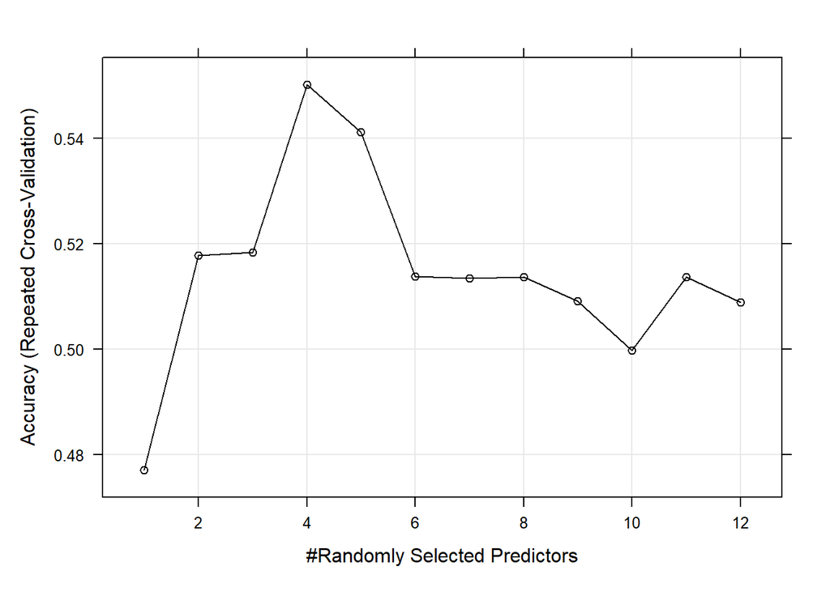

```r
## some plots
trellis.par.set(caretTheme())
plot(forestfit)
```

```r
## make predictions on the hold-out set
predvals <- predict(forestfit, holdoutTransformed)

## create the confusion matrix and view the results
confusionMatrix(predvals, holdoutTransformed$Chest.pain.type, positive = "more.than.50.pct")
```

```
## Confusion Matrix and Statistics
##
##           Reference
## Prediction TA ATA NAP ASY
##        TA   0   0   0   0
##        ATA  0   0   4   2
##        NAP  1   6   4   6
##        ASY  3   2   7  17
##
## Overall Statistics
##
##                Accuracy : 0.4038
##                  95% CI : (0.2701, 0.549)
##     No Information Rate : 0.4808
##     P-Value [Acc > NIR] : 0.8946
##
##                   Kappa : 0.0382
##
##  Mcnemar's Test P-Value : NA
##
## Statistics by Class:
##
##                      Class: TA Class: ATA Class: NAP Class: ASY
## Sensitivity            0.00000     0.0000    0.26667     0.6800
## Specificity            1.00000     0.8636    0.64865     0.5556
## Pos Pred Value             NaN     0.0000    0.23529     0.5862
## Neg Pred Value         0.92308     0.8261    0.68571     0.6522
## Prevalence             0.07692     0.1538    0.28846     0.4808
## Detection Rate         0.00000     0.0000    0.07692     0.3269
## Detection Prevalence   0.00000     0.1154    0.32692     0.5577
## Balanced Accuracy      0.50000     0.4318    0.45766     0.6178
```

```r
## Rank the variables in terms of their importance
varImp(forestfit)
```

```
## rf variable importance
##
##                                         Overall
## Max.HR                                  100.000
## Cholesterol                              93.205
## Age                                      89.834
## BP                                       84.069
## ST.depression                            67.901
## Exercise.anginayes                       52.075
## EKG.resultsventricular.hypertrophy       21.903
## Thalliumreversible.defect                21.354
## Number.of.vessels.fluromore.than.50.pct  20.074
## SexM                                     17.847
## Slope.of.STflat                          17.637
## FBS.over.120true                         14.622
## Thalliumfixed.defect                      5.719
## Slope.of.STdownsloping                    4.508
## EKG.resultswave.abnormality               0.000
```

```r
## next, let's identify an optimal boosted-tree model
## Consulting the documentation, https://topepo.github.io/caret/train-models-by-tag.html#boosting
## we find that there are several implementations of boosted models available
## to be consistent with chapter 8 in the book, we will use the package gbm
## and the gbm method present in it for fitting an optimal boosted-tree model.
## all of the initial set-up steps will remain the same. The changes (new code)
## begin(s) with setting up the dataframe that has method-specific parameters
## and their ranges of values. The specific columns to use are described
## in the gbm documentation:
# Tuning parameters:
#   n.trees (# Boosting Iterations)
#     interaction.depth (Max Tree Depth)
#     shrinkage (Shrinkage)
#     n.minobsinnode (Min. Terminal Node Size)

grid <- expand.grid(interaction.depth = seq(1:3),
                    shrinkage = seq(from = 0.01, to = 0.2, by = 0.01),
                    n.trees = seq(from = 100, to = 500, by = 100),
                    n.minobsinnode = seq(from = 5, to = 15, by = 5)
)


boostedfit <- train(Chest.pain.type ~ .,
                    data = trainTransformed,
                    method = "gbm",
                    trControl = fitControl,
                    verbose = FALSE,
                    tuneGrid = grid)
## check what information is available for the model fit
names(boostedfit)
```

```
##  [1] "method"       "modelInfo"    "modelType"    "results"      "pred"
##  [6] "bestTune"     "call"         "dots"         "metric"       "control"
## [11] "finalModel"   "preProcess"   "trainingData" "ptype"        "resample"
## [16] "resampledCM"  "perfNames"    "maximize"     "yLimits"      "times"
## [21] "levels"       "terms"        "coefnames"    "contrasts"    "xlevels"
```

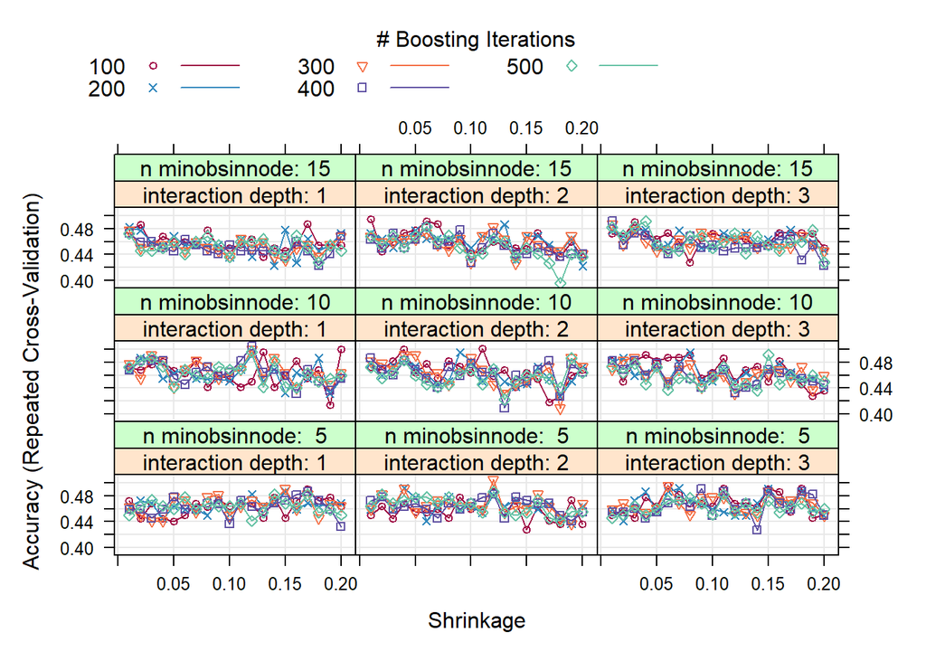

```r
## some plots
trellis.par.set(caretTheme())
plot(boostedfit)
```

```r
## make predictions on the hold-out set
predvals <- predict(boostedfit, holdoutTransformed)

## compute the performance metrics
confusionMatrix(predvals, holdoutTransformed$Chest.pain.type)
```

```
## Confusion Matrix and Statistics
##
##           Reference
## Prediction TA ATA NAP ASY
##        TA   0   0   3   1
##        ATA  1   1   5   3
##        NAP  0   3   4   5
##        ASY  3   4   3  16
##
## Overall Statistics
##
##                Accuracy : 0.4038
##                  95% CI : (0.2701, 0.549)
##     No Information Rate : 0.4808
##     P-Value [Acc > NIR] : 0.8946
##
##                   Kappa : 0.0934
##
##  Mcnemar's Test P-Value : 0.4074
##
## Statistics by Class:
##
##                      Class: TA Class: ATA Class: NAP Class: ASY
## Sensitivity            0.00000    0.12500    0.26667     0.6400
## Specificity            0.91667    0.79545    0.78378     0.6296
## Pos Pred Value         0.00000    0.10000    0.33333     0.6154
## Neg Pred Value         0.91667    0.83333    0.72500     0.6538
## Prevalence             0.07692    0.15385    0.28846     0.4808
## Detection Rate         0.00000    0.01923    0.07692     0.3077
## Detection Prevalence   0.07692    0.19231    0.23077     0.5000
## Balanced Accuracy      0.45833    0.46023    0.52523     0.6348
```

```r
## Rank the variables in terms of their importance
varImp(boostedfit)
```

```
## gbm variable importance
##
##                                           Overall
## Max.HR                                  100.00000
## Cholesterol                              91.61395
## Age                                      75.59574
## BP                                       70.73654
## ST.depression                            37.43820
## Exercise.anginayes                       18.18513
## Thalliumreversible.defect                 9.01262
## SexM                                      7.14636
## EKG.resultsventricular.hypertrophy        6.67734
## FBS.over.120true                          6.26255
## Number.of.vessels.fluromore.than.50.pct   4.57975
## Slope.of.STflat                           3.30890
## Thalliumfixed.defect                      0.38169
## Slope.of.STdownsloping                    0.04615
## EKG.resultswave.abnormality               0.00000
```

```r
## comparing the results of the randomforest algorithm with those from
## the gbm algorithm, which one performed better? What about the values
## of variable importance - did the ranking stay the same or change?

stopCluster(cl)
```

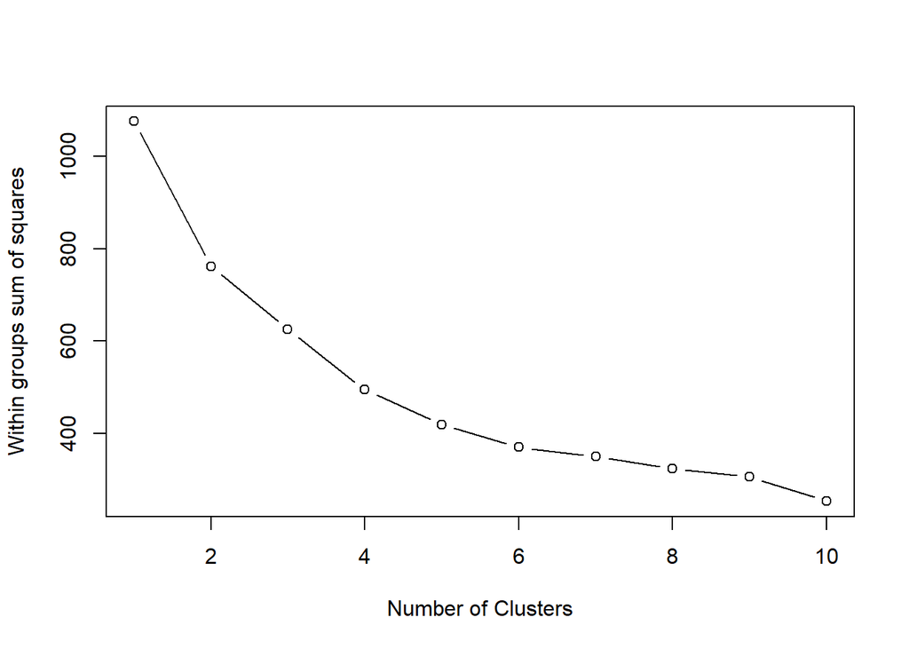

```r
#kmeans clustring

dsobject <- na.omit(read.csv("C:/Users/sathw/Desktop/Heart_Disease_Prediction (1).csv", header = TRUE, sep = ",",
                             na.strings = "?"))
View(dsobject)

# Select only the necessary columns for clustering
clustering_data <- dsobject[,c(3,13,5,12)]

# Scale the data
scaled_data <- scale(clustering_data)

wss <- (nrow(scaled_data)-1)*sum(apply(scaled_data,2,var))
for (i in 2:10) wss[i] <- sum(kmeans(scaled_data, centers=i)$withinss)
plot(1:10, wss, type="b", xlab="Number of Clusters", ylab="Within groups sum of squares")
```

```r
# Based on the plot, choose k=2
k <- 2

# Cluster the data
kmeans_result <- kmeans(scaled_data, centers=k)

# Print the cluster centers and sizes
cat("Cluster Centers:\n")
```

```
## Cluster Centers:
```

```r
print(kmeans_result$centers)
```

```
##   Chest.pain.type   Thallium Cholesterol Number.of.vessels.fluro
## 1      -0.4429341 -0.6967429 -0.06388773              -0.4350373
## 2       0.5880333  0.9249863  0.08481647               0.5775495
```

```r
cat("Cluster Sizes:\n")
```

```
## Cluster Sizes:
```

```r
print(kmeans_result$size)
```

```
## [1] 154 116
```

```r
# Add the cluster labels to the original data
dsobject$cluster <- kmeans_result$cluster

# View the resulting data
head(dsobject)
```

```
##   Age Sex Chest.pain.type  BP Cholesterol FBS.over.120 EKG.results Max.HR
## 1  70   1               4 130         322            0           2    109
## 2  67   0               3 115         564            0           2    160
## 3  57   1               2 124         261            0           0    141
## 4  64   1               4 128         263            0           0    105
## 5  74   0               2 120         269            0           2    121
## 6  65   1               4 120         177            0           0    140
##   Exercise.angina ST.depression Slope.of.ST Number.of.vessels.fluro Thallium
## 1               0           2.4           2                       3        3
## 2               0           1.6           2                       0        7
## 3               0           0.3           1                       0        7
## 4               1           0.2           2                       1        7
## 5               1           0.2           1                       1        3
## 6               0           0.4           1                       0        7
##   Heart.Disease cluster
## 1      Presence       2
## 2       Absence       2
## 3      Presence       1
## 4       Absence       2
## 5       Absence       1
## 6       Absence       2
```

```r
summary(clustering_data)
```

```
##  Chest.pain.type    Thallium      Cholesterol    Number.of.vessels.fluro
##  Min.   :1.000   Min.   :3.000   Min.   :126.0   Min.   :0.0000
##  1st Qu.:3.000   1st Qu.:3.000   1st Qu.:213.0   1st Qu.:0.0000
##  Median :3.000   Median :3.000   Median :245.0   Median :0.0000
##  Mean   :3.174   Mean   :4.696   Mean   :249.7   Mean   :0.6704
##  3rd Qu.:4.000   3rd Qu.:7.000   3rd Qu.:280.0   3rd Qu.:1.0000
##  Max.   :4.000   Max.   :7.000   Max.   :564.0   Max.   :3.0000
```

```r
#SVM linear
library(MASS)
library(randomForest)
library(gbm)
library(caret)
library(doParallel)
library(ggplot2)
library(plyr)
cores <- detectCores()
cl <- makePSOCKcluster(cores) #or cores-1
registerDoParallel(cl)

dsobject <- na.omit(read.csv("C:/Users/sathw/Desktop/Heart_Disease_Prediction (1).csv", header = TRUE, sep = ",",
                             na.strings = "?"))
summary(dsobject)
```

```
##       Age             Sex         Chest.pain.type       BP
##  Min.   :29.00   Min.   :0.0000   Min.   :1.000   Min.   : 94.0
##  1st Qu.:48.00   1st Qu.:0.0000   1st Qu.:3.000   1st Qu.:120.0
##  Median :55.00   Median :1.0000   Median :3.000   Median :130.0
##  Mean   :54.43   Mean   :0.6778   Mean   :3.174   Mean   :131.3
##  3rd Qu.:61.00   3rd Qu.:1.0000   3rd Qu.:4.000   3rd Qu.:140.0
##  Max.   :77.00   Max.   :1.0000   Max.   :4.000   Max.   :200.0
##   Cholesterol     FBS.over.120     EKG.results        Max.HR
##  Min.   :126.0   Min.   :0.0000   Min.   :0.000   Min.   : 71.0
##  1st Qu.:213.0   1st Qu.:0.0000   1st Qu.:0.000   1st Qu.:133.0
##  Median :245.0   Median :0.0000   Median :2.000   Median :153.5
##  Mean   :249.7   Mean   :0.1481   Mean   :1.022   Mean   :149.7
##  3rd Qu.:280.0   3rd Qu.:0.0000   3rd Qu.:2.000   3rd Qu.:166.0
##  Max.   :564.0   Max.   :1.0000   Max.   :2.000   Max.   :202.0
##  Exercise.angina  ST.depression   Slope.of.ST    Number.of.vessels.fluro
##  Min.   :0.0000   Min.   :0.00   Min.   :1.000   Min.   :0.0000
##  1st Qu.:0.0000   1st Qu.:0.00   1st Qu.:1.000   1st Qu.:0.0000
##  Median :0.0000   Median :0.80   Median :2.000   Median :0.0000
##  Mean   :0.3296   Mean   :1.05   Mean   :1.585   Mean   :0.6704
##  3rd Qu.:1.0000   3rd Qu.:1.60   3rd Qu.:2.000   3rd Qu.:1.0000
##  Max.   :1.0000   Max.   :6.20   Max.   :3.000   Max.   :3.0000
##     Thallium     Heart.Disease
##  Min.   :3.000   Length:270
##  1st Qu.:3.000   Class :character
##  Median :3.000   Mode  :character
##  Mean   :4.696
##  3rd Qu.:7.000
##  Max.   :7.000
```

[figure not shown]

```r
ggpairs(dsobject)
```

```r
##view updated summary of data after factors are converted
dsobject$Sex <- factor(dsobject$Sex,
                       levels = c(0, 1),
                       labels = c("F", "M"))

dsobject$Chest.pain.type <- factor(dsobject$Chest.pain.type,
                                   levels = c(1, 2, 3, 4),
                                   labels = c("TA", "ATA",
                                              "NAP", "ASY"))

dsobject$FBS.over.120 <- factor(dsobject$FBS.over.120,
                                levels = c(0, 1),
                                labels = c("false", "true"))

dsobject$EKG.results <- factor(dsobject$EKG.results,
                               levels = c(0, 1, 2),
                               labels = c("normal", "wave.abnormality",
                                          "ventricular.hypertrophy"))

dsobject$Exercise.angina <- factor(dsobject$Exercise.angina, levels = c(0, 1),
                                   labels = c("no", "yes"))

dsobject$Slope.of.ST <- factor(dsobject$Slope.of.ST,
                               levels = c(1, 2, 3),
                               labels = c("upsloping", "flat", "downsloping"))

dsobject$Thallium <- factor(dsobject$Thallium,
                            levels = c(3, 6, 7),
                            labels = c("normal", "fixed.defect", "reversible.defect"))

dsobject$Number.of.vessels.fluro <- as.factor(ifelse(dsobject$Number.of.vessels.fluro == 0, 0, 1))
dsobject$Number.of.vessels.fluro <- factor(dsobject$Number.of.vessels.fluro,
                                           levels = c(0, 1),
                                           labels = c("less.than.50.pct", "more.than.50.pct"))


dsobject <- dsobject[, -14] ## remove the previous version of num
summary(dsobject)
```

```
##       Age        Sex     Chest.pain.type       BP         Cholesterol
##  Min.   :29.00   F: 87   TA : 20         Min.   : 94.0   Min.   :126.0
##  1st Qu.:48.00   M:183   ATA: 42         1st Qu.:120.0   1st Qu.:213.0
##  Median :55.00           NAP: 79         Median :130.0   Median :245.0
##  Mean   :54.43           ASY:129         Mean   :131.3   Mean   :249.7
##  3rd Qu.:61.00                           3rd Qu.:140.0   3rd Qu.:280.0
##  Max.   :77.00                           Max.   :200.0   Max.   :564.0
##  FBS.over.120                  EKG.results      Max.HR      Exercise.angina
##  false:230    normal                 :131   Min.   : 71.0   no :181
##  true : 40    wave.abnormality       :  2   1st Qu.:133.0   yes: 89
##               ventricular.hypertrophy:137   Median :153.5
##                                             Mean   :149.7
##                                             3rd Qu.:166.0
##                                             Max.   :202.0
##  ST.depression       Slope.of.ST      Number.of.vessels.fluro
##  Min.   :0.00   upsloping  :130   less.than.50.pct:160
##  1st Qu.:0.00   flat       :122   more.than.50.pct:110
##  Median :0.80   downsloping: 18
##  Mean   :1.05
##  3rd Qu.:1.60
##  Max.   :6.20
##               Thallium
##  normal           :152
##  fixed.defect     : 14
##  reversible.defect:104
##
##
##
```

```r
## identify any predictors that have zero or near-zero variance
nzv <- nearZeroVar(dsobject, saveMetrics= TRUE)
nzv ## run and see if there are any non-varying variables
```

```
##                         freqRatio percentUnique zeroVar   nzv
## Age                      1.066667    15.1851852   FALSE FALSE
## Sex                      2.103448     0.7407407   FALSE FALSE
## Chest.pain.type          1.632911     1.4814815   FALSE FALSE
## BP                       1.096774    17.4074074   FALSE FALSE
## Cholesterol              1.200000    53.3333333   FALSE FALSE
## FBS.over.120             5.750000     0.7407407   FALSE FALSE
## EKG.results              1.045802     1.1111111   FALSE FALSE
## Max.HR                   1.111111    33.3333333   FALSE FALSE
## Exercise.angina          2.033708     0.7407407   FALSE FALSE
## ST.depression            6.071429    14.4444444   FALSE FALSE
## Slope.of.ST              1.065574     1.1111111   FALSE FALSE
## Number.of.vessels.fluro  1.454545     0.7407407   FALSE FALSE
## Thallium                 1.461538     1.1111111   FALSE FALSE
```